# Kto odpowiada ankieterowi?

**Diagnoza nieignorowalnego braku odpowiedzi za pomocą losowego instrumentu odpowiedzi**

Ben Stanley

Uniwersytet SWPS

17 września 2026

## Sondaże mają problem

- Wskaźniki odpowiedzi się załamały: w typowym polskim sondażu internetowym (CAWI) ankietę wypełnia **mniej niż co dziesiąta zaproszona osoba**.
- Wszystko, o czym informujemy — prognozy frekwencji, poparcie partii, postawy wobec demokracji — pochodzi od małej, samoselekcjonującej się grupy, która *zechciała* odpowiedzieć.
- Standardową naprawą jest **ważenie**: dopasowujemy próbę do populacji pod względem wieku, płci, wykształcenia i miejsca zamieszkania.
- Ważenie opiera się na jednym potężnym założeniu: **osoby, które odpowiadają, są takie same jak te, które nie odpowiadają — o ile zgadzają się cechy demograficzne.**

## Gdy założenie zawodzi: nieignorowalny brak odpowiedzi

- Dla wielu pytań założenie jest w porządku. Dla niektórych zawodzi z hukiem: **sama treść odpowiedzi jest powiązana ze skłonnością do udziału w badaniu.**
  - Zaangażowani politycznie lubią sondaże polityczne — i częściej głosują.
  - Nieufni unikają ankieterów — i mają odrębne poglądy.
- To **nieignorowalny brak odpowiedzi** (Bailey 2024): brakujący różnią się *opiniami*, a nie tylko demografią — problem niewidoczny dla wag demograficznych.

## Świat syntetyczny

- Symulujemy kraj liczący 100 000 osób, więc prawdziwe odpowiedzi są **znane dokładnie**.
- Dwie ukryte cechy wpływają zarówno na to, *czy* ludzie odpowiadają, jak i na to, *co* myślą:
  - **zaangażowanie polityczne** — ↑ odpowiedzi; ↑ frekwencja, postawy przychylne mniejszościom i prodemokratyczne;
  - **zaufanie do instytucji** — ↑ odpowiedzi; ↓ poparcie dla stygmatyzowanej partii antyestablishmentowej.
- Sześć pytań: cztery, w których ukryte cechy mają znaczenie (**flagowane**), i dwa zależne wyłącznie od demografii (**kontrolne**: poparcie dla UE, palenie papierosów).
- Realizujemy badanie wśród 30 000 losowo zaproszonych osób — z jedną wbudowaną sztuczką.

## Projekt badania: losujemy protokół kontaktu

```
flowchart LR
    I["30 000 zaproszonych<br>(próba losowa)"] --> R{{"losowy podział<br>50 / 50"}}
    R --> A["<b>Ramię A — kontakt standardowy</b><br>zaproszenie + przypomnienia + dodatkowe punkty"]
    R --> B["<b>Ramię B — lekki kontakt</b><br>jedno zaproszenie, potem cisza"]
    A --> RA["odpowiada 20,7% (n = 3 096)<br><i>typy chętne <b>i</b> niechętne</i>"]
    B --> RB["odpowiada 5,7% (n = 853)<br><i>tylko najbardziej chętni</i>"]
    style A fill:#e8e8e8,stroke:#555
    style B fill:#fdeceb,stroke:#9B0000
```

- **Porównujemy odpowiedzi, pytanie po pytaniu**: takie same → brak odpowiedzi ignorowalny, ważenie wystarcza; różne → obciążenie wykryte.
- Ten losowo przydzielony bodziec to **losowy instrument odpowiedzi** (Bailey 2024, rozdz. 10): zmienia to, *czy* ludzie odpowiadają, nie zmieniając tego, *co myślą*.

## Dlaczego średnia z respondentów jest obciążona

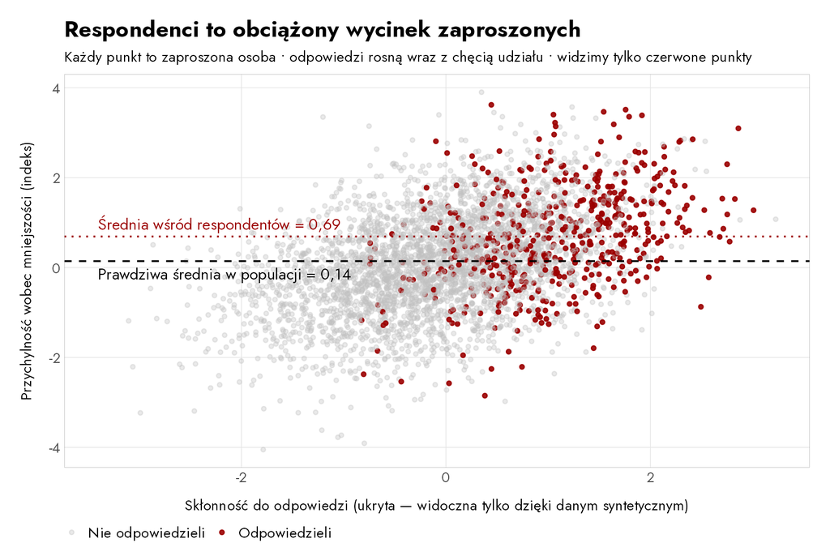

## Instrument działa

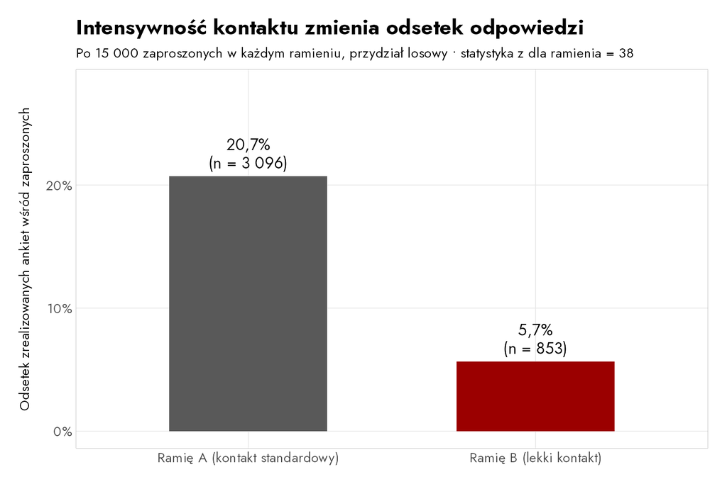

- **Różnica 15 punktów procentowych** w odsetku odpowiedzi, wywołana losowo przydzieloną intensywnością kontaktu: warunek *włączenia* jest spełniony.

## Ramiona różnią się dokładnie tam, gdzie powinny

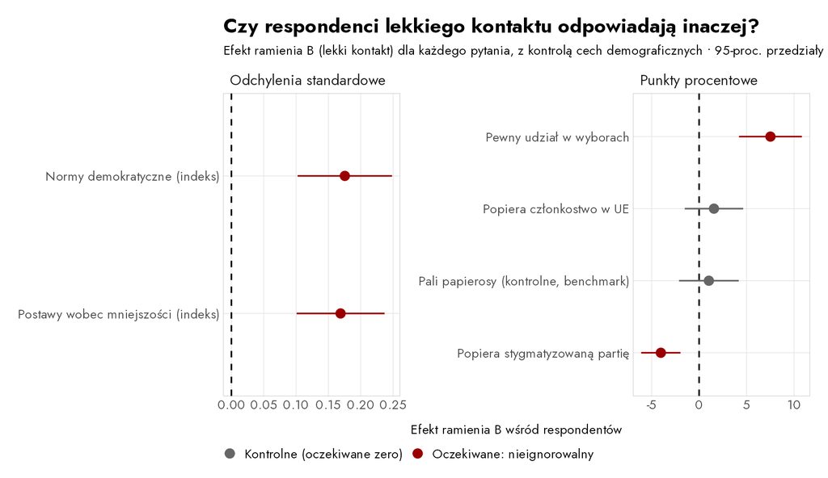

Respondenci lekkiego kontaktu deklarują **wyższą** frekwencję (+7,5 pp), **niższe** poparcie dla stygmatyzowanej partii (-4,0 pp) i **bardziej** progresywne postawy — a oba pytania kontrolne siedzą na zerze.

## Ważenie nie ratuje flagowanych pytań

| Pytanie | Prawda | Sondaż (surowy) | Po ważeniu | Nadal błąd |
| --- | --- | --- | --- | --- |
| Pewny udział w wyborach | 49,9% | 69,5% | 68,9% | **+19,0 pp** |
| Stygmatyzowana partia | 19,7% | 10,4% | 10,1% | **−9,6 pp** |
| Postawy wobec mniejszości | 0,14 | 0,69 | 0,64 | **+0,50** |
| Poparcie dla UE (kontrolne) | 76,9% | 77,9% | 77,2% | ✓ w porządku |
| Palenie (kontrolne) | 21,9% | 21,8% | 22,0% | ✓ w porządku |

- Ważenie dopasowuje próbę do populacji pod względem wszystkich cech demograficznych — a flagowane oszacowania ledwie drgnęły.

## Model selekcji z instrumentem odzyskuje prawdę

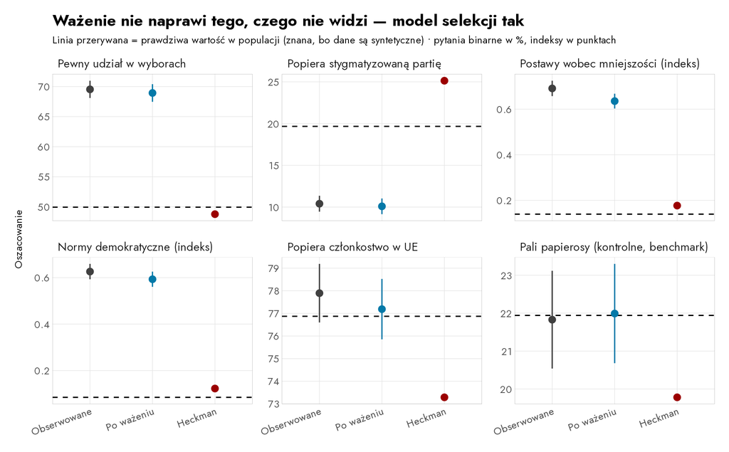

## Odczytanie wyników według drzewa decyzyjnego Baileya

| Pytanie | ρ̂ (korelacja selekcja–odpowiedź) | Werdykt | Właściwe narzędzie |
| --- | --- | --- | --- |
| Pewny udział w wyborach | 0,33 (z = 4,7) | nieignorowalny | model selekcji |
| Stygmatyzowana partia | -0,36 (z = -4,0) | nieignorowalny | model selekcji |
| Postawy wobec mniejszości | 0,28 (z = 5,1) | nieignorowalny | model selekcji |
| Normy demokratyczne | 0,29 (z = 5,1) | nieignorowalny | model selekcji |
| Poparcie dla UE | 0,08 (z = 0,9) | ignorowalny | **dalej ważyć** |
| Palenie | 0,05 (z = 0,6) | ignorowalny | **dalej ważyć** |

- Tam, gdzie ρ̂ ≈ 0, ważenie jest *lepsze* — model selekcji dodaje szum, którego nie potrzebujemy.

## Sondaże wyolbrzymiają polaryzację

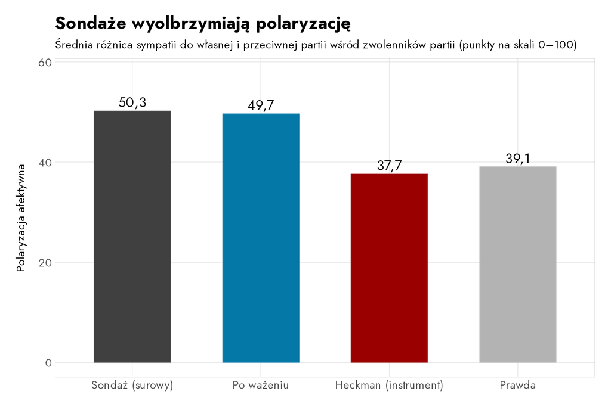

Zaangażowani zwolennicy partii częściej odpowiadają *i* żywią większą niechęć do drugiej strony, więc obserwowana różnica (50,3) zawyża prawdziwą (39,1). Bailey znalazł dokładnie to samo w USA: chętni Demokraci i chętni Republikanie są bardziej skrajni niż ich milczący współpartyjnicy.

## Pilotaż FRBN

- **Ok. 2000 zrealizowanych ankiet** z polskiego panelu CAWI; ok. 18 500 zaproszeń dzielonych losowo w proporcji 42/58 na kontakt **intensywny** (zaproszenie + trzy przypomnienia) i **lekki**; agencja oznacza każdy wywiad ramieniem i falą przypomnienia.
- Kwestionariusz łączy pytania, w których spodziewamy się obciążenia nieignorowalnym brakiem odpowiedzi (frekwencja, partie stygmatyzowane, mniejszości, normy demokratyczne), z pytaniami **kontrolnymi** — w tym z benchmarkiem w statystyce publicznej i wynikach wyborów.
- **Prerejestracja** hipotez, testów i reguł decyzyjnych; pełny kod i zanonimizowane dane zostaną opublikowane.
- Rezultat: dla każdego konstruktu — **jak silnie skłonność do odpowiedzi wiąże się z jej treścią, wraz z przedziałem** — oraz **zwalidowany protokół wielokrotnego użytku** dla PGSW i wielkości efektów potrzebne badaniu w pełnej skali.

## Co pilotaż tej wielkości rozstrzygnie, a czego nie

- Analizę zbudowaliśmy i uruchomiliśmy **na danych symulowanych, zanim ruszy badanie** — i tak właśnie odkryliśmy, że przy dwóch przypomnieniach kluczowe testy wykrywałyby spodziewane efekty mniej więcej **raz na dziesięć prób**.
- Wiążącym ograniczeniem jest **różnica odsetków odpowiedzi**, a nie liczba wywiadów: próba daje √n, protokół kontaktu daje różnicę. Stąd trzy przypomnienia i próg „idziemy / nie idziemy” po miękkim starcie ustawiony na mocy testu, a nie na poprawności instrumentu.
- Mimo to: część pytań wróci jako **nierozstrzygnięte**. Uczciwym produktem jest oszacowanie z przedziałem, a nie werdykt przy każdym pytaniu.
- I po to właśnie robi się pilotaż — a to dokładnie to, czego potrzebuje wniosek NCN OPUS, żeby mieć odpowiednią moc.